# R Programming

A Tour of Statistical Software Design

Fernando Millan Villalobos

2022-08-15

# 1 Notes

This report was generated on 2022-08-15 11:48:57. R version: 4.2.0 on x86_64-apple-darwin17.0. For this report, CRAN packages as of 2022-05-01 were used.

…

## 1.1 R-Script & data

The preprocessing and analysis of the data was conducted in the [R project for statistical computing](https://www.r-project.org/). The RMarkdown script used to generate this document and all the resulting data can be downloaded [under this link](http://fernandomillanvillalobos.github.io/art-programming-r/). Through executing `main.Rmd`, the herein described process can be reproduced and this document can be generated. In the course of this, data from the folder `input` will be processed and results will be written to `output`. The html on-line version of the analysis can be accessed through this [link](https://fernandomillanvillalobos.github.io/art-programming-r/).

## 1.2 GitHub

The code for the herein described process can also be freely downloaded from https://github.com/fernandomillanvillalobos/art-programming-r.

## 1.3 License

…

## 1.4 Data description of output files

#### 1.4.0.1 `abc.csv` (Example)

| Attribute | Type | Description |
| --- | --- | --- |
| a | Numeric | … |
| b | Numeric | … |
| c | Numeric | … |

…

# 2 Set up

```
## [1] "package package:rmarkdown detached"
```

## 2.1 Define packages

```r
# from https://mran.revolutionanalytics.com/web/packages/\
# checkpoint/vignettes/using-checkpoint-with-knitr.html
# if you don't need a package, remove it from here (commenting not sufficient)
# tidyverse: see https://blog.rstudio.org/2016/09/15/tidyverse-1-0-0/
cat("
library(rstudioapi)
library(tidyverse)
library(tidylog)
library(jsonlite)
library(lintr)
library(rmarkdown)
library(rio)
library(cowplot)
library(extrafont)
library(ggrepel)
library(scales)
library(regtools)
library(openintro)
library(janitor)",
file = "manifest.R")
```

## 2.2 Install packages

```r
# if checkpoint is not yet installed, install it (for people using this
# system for the first time)
if (!require(checkpoint)) {
  if (!require(devtools)) {
    install.packages("devtools", repos = "http://cran.us.r-project.org")
    require(devtools)
  }
  devtools::install_github("RevolutionAnalytics/checkpoint",
                           ref = "v0.3.2", # could be adapted later,
                           # as of now (beginning of July 2017
                           # this is the current release on CRAN)
                           repos = "http://cran.us.r-project.org")
  require(checkpoint)
}
# nolint start
if (!dir.exists("~/.checkpoint")) {
  dir.create("~/.checkpoint")
}
# nolint end
# install packages for the specified CRAN snapshot date
checkpoint(snapshot_date = package_date,
           project = path_to_wd,
           verbose = T,
           scanForPackages = T,
           use.knitr = F,
           R.version = r_version)
rm(package_date)
```

## 2.3 Load packages

```r
source("manifest.R")
unlink("manifest.R")
```

## 2.4 Load additional scripts

```r
# if you want to outsource logic to other script files, see README for
# further information
# Load all visualizations functions as separate scripts
knitr::read_chunk("scripts/dviz.supp.R")
source("scripts/dviz.supp.R")
knitr::read_chunk("scripts/themes.R")
source("scripts/themes.R")
knitr::read_chunk("scripts/plot_grid.R")
source("scripts/plot_grid.R")
knitr::read_chunk("scripts/align_legend.R")
source("scripts/align_legend.R")
knitr::read_chunk("scripts/label_log10.R")
source("scripts/label_log10.R")
knitr::read_chunk("scripts/outliers.R")
source("scripts/outliers.R")
```

# 3 Use Base-R, Not the Tidyverse: An opinionated view of the Tidyverse “dialect” of the R language

Based on [Norm Matloff’s](https://heather.cs.ucdavis.edu/matloff.html) article [Teaching R in a Kinder, Gentler, More Effective Manner:Use Base-R, Not the Tidyverse](https://github.com/matloff/TidyverseSkeptic).

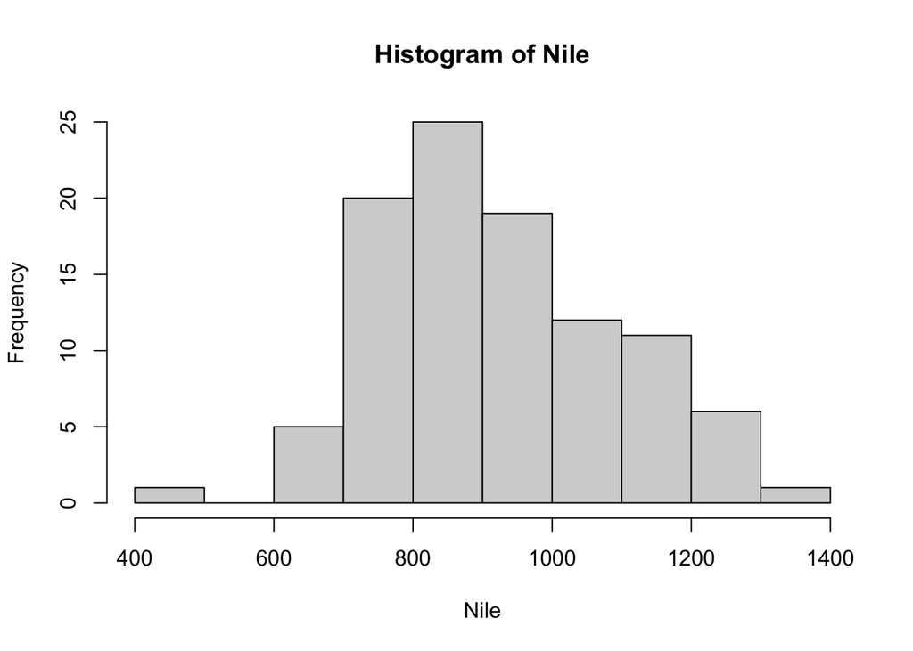

```r
# base-R
hist(Nile)
```

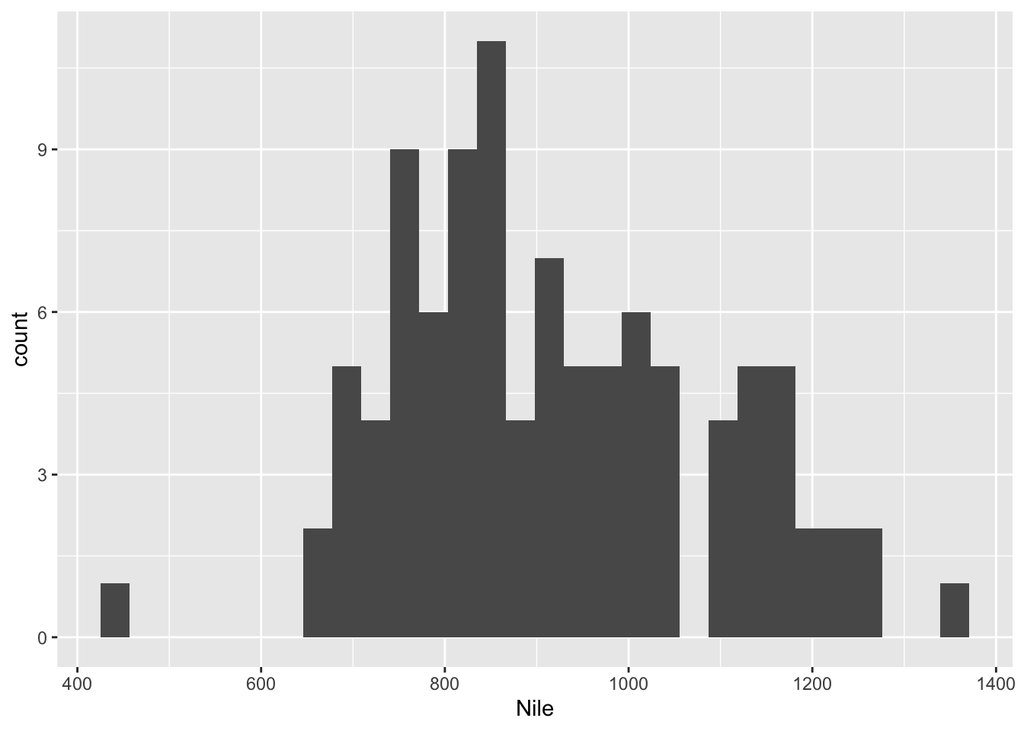

```r
# Tidy
dn <- data.frame(Nile)
ggplot(dn) +
  geom_histogram(aes(Nile), dn)
```

```r
mean(Nile[80:100])
```

```
## [1] 877.6667
```

```r
# Case study: tapply()
# tapply(what to split, how to split it, what to apply to the resulting chunks)

# 1) base-R
aggregate(airquality[, "Ozone"],
  list(Month = airquality[, "Month"]),
  mean,
  na.rm = TRUE
)
```

```
##   Month        x
## 1     5 23.61538
## 2     6 29.44444
## 3     7 59.11538
## 4     8 59.96154
## 5     9 31.44828
```

```r
# 2) base-R
aq <- na.omit(airquality)
tapply(aq$Ozone, aq$Month, mean)
```

```
##        5        6        7        8        9
## 24.12500 29.44444 59.11538 60.00000 31.44828
```

```r
# Tidy
group_by(airquality, Month) %>%
  summarize(o3 = mean(Ozone, na.rm = TRUE))
```

```
## # A tibble: 5 × 2
##   Month    o3
##   <int> <dbl>
## 1     5  23.6
## 2     6  29.4
## 3     7  59.1
## 4     8  60.0
## 5     9  31.4
```

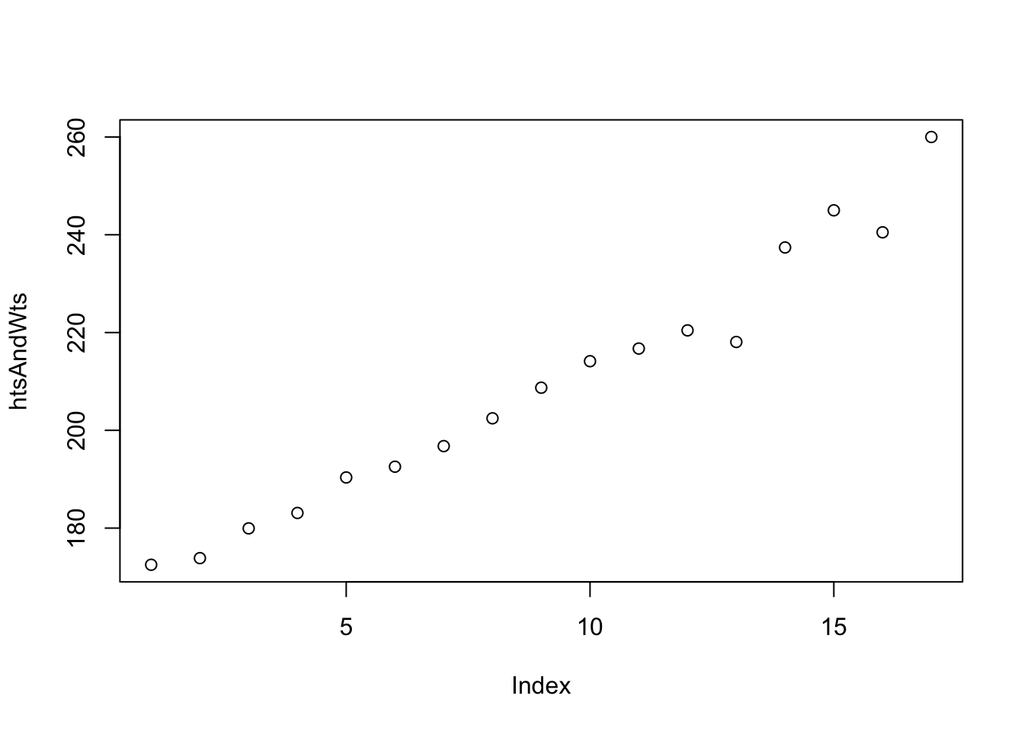

```r
# Case study: tapply (II)
data("mlb", package = "regtools")
htsAndWts <- tapply(mlb$Weight, mlb$Height, mean)
plot(htsAndWts)
```

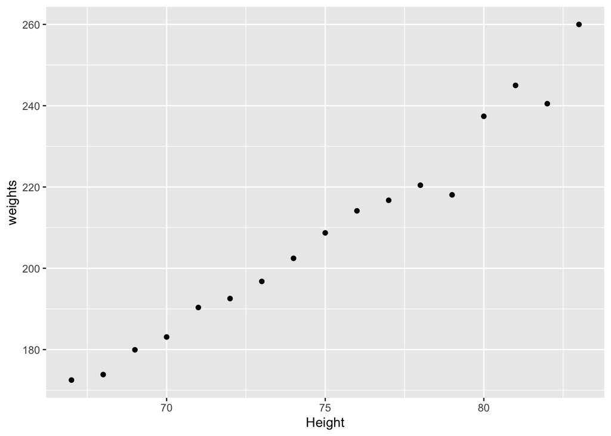

```r
# Tidy
mlb %>%
  group_by(Height) %>%
  summarize(weights = mean(Weight)) %>%
  ggplot(aes(x = Height, y = weights)) +
  geom_point()
```

```r
# avoiding $ use
# Tidy
loans_tidy <- openintro::loans_full_schema %>%
  mutate(
    homeownership = str_to_title(homeownership),
    bankruptcy = if_else(public_record_bankrupt >= 1, "Yes", "No")
  ) %>%
  filter(annual_income >= 10)
loans_tidy
```

```
## # A tibble: 9,976 × 56
##    emp_t…¹ emp_l…² state homeo…³ annua…⁴ verif…⁵ debt_…⁶ annua…⁷ verif…⁸ debt_…⁹
##    <chr>     <dbl> <fct> <chr>     <dbl> <fct>     <dbl>   <dbl> <fct>     <dbl>
##  1 "globa…       3 NJ    Mortga…   90000 Verifi…   18.0       NA ""         NA
##  2 "wareh…      10 HI    Rent      40000 Not Ve…    5.04      NA ""         NA
##  3 "assem…       3 WI    Rent      40000 Source…   21.2       NA ""         NA
##  4 "custo…       1 PA    Rent      30000 Not Ve…   10.2       NA ""         NA
##  5 "secur…      10 CA    Rent      35000 Verifi…   58.0    57000 "Verif…    37.7
##  6 ""           NA KY    Own       34000 Not Ve…    6.46      NA ""         NA
##  7 "hr "        10 MI    Mortga…   35000 Source…   23.7   155000 "Not V…    13.1
##  8 "polic…      10 AZ    Mortga…  110000 Source…   16.2       NA ""         NA
##  9 "parts"      10 NV    Mortga…   65000 Source…   36.5       NA ""         NA
## 10 "4th p…       3 IL    Rent      30000 Not Ve…   18.9       NA ""         NA
## # … with 9,966 more rows, 46 more variables: delinq_2y <int>,
## #   months_since_last_delinq <int>, earliest_credit_line <dbl>,
## #   inquiries_last_12m <int>, total_credit_lines <int>,
## #   open_credit_lines <int>, total_credit_limit <int>,
## #   total_credit_utilized <int>, num_collections_last_12m <int>,
## #   num_historical_failed_to_pay <int>, months_since_90d_late <int>,
## #   current_accounts_delinq <int>, total_collection_amount_ever <int>, …
## # ℹ Use `print(n = ...)` to see more rows, and `colnames()` to see all variable names
```

```r
# base-R
loans_base <- openintro::loans_full_schema
loans_base$bankruptcy <- ifelse(loans_base$public_record_bankrupt >= 1, "Yes", "No")
subset(loans_base, annual_income >= 10)
```

```
## # A tibble: 9,976 × 56
##    emp_t…¹ emp_l…² state homeo…³ annua…⁴ verif…⁵ debt_…⁶ annua…⁷ verif…⁸ debt_…⁹
##    <chr>     <dbl> <fct> <fct>     <dbl> <fct>     <dbl>   <dbl> <fct>     <dbl>
##  1 "globa…       3 NJ    MORTGA…   90000 Verifi…   18.0       NA ""         NA
##  2 "wareh…      10 HI    RENT      40000 Not Ve…    5.04      NA ""         NA
##  3 "assem…       3 WI    RENT      40000 Source…   21.2       NA ""         NA
##  4 "custo…       1 PA    RENT      30000 Not Ve…   10.2       NA ""         NA
##  5 "secur…      10 CA    RENT      35000 Verifi…   58.0    57000 "Verif…    37.7
##  6 ""           NA KY    OWN       34000 Not Ve…    6.46      NA ""         NA
##  7 "hr "        10 MI    MORTGA…   35000 Source…   23.7   155000 "Not V…    13.1
##  8 "polic…      10 AZ    MORTGA…  110000 Source…   16.2       NA ""         NA
##  9 "parts"      10 NV    MORTGA…   65000 Source…   36.5       NA ""         NA
## 10 "4th p…       3 IL    RENT      30000 Not Ve…   18.9       NA ""         NA
## # … with 9,966 more rows, 46 more variables: delinq_2y <int>,
## #   months_since_last_delinq <int>, earliest_credit_line <dbl>,
## #   inquiries_last_12m <int>, total_credit_lines <int>,
## #   open_credit_lines <int>, total_credit_limit <int>,
## #   total_credit_utilized <int>, num_collections_last_12m <int>,
## #   num_historical_failed_to_pay <int>, months_since_90d_late <int>,
## #   current_accounts_delinq <int>, total_collection_amount_ever <int>, …
## # ℹ Use `print(n = ...)` to see more rows, and `colnames()` to see all variable names
```

```r
loans_base
```

```
## # A tibble: 10,000 × 56
##    emp_t…¹ emp_l…² state homeo…³ annua…⁴ verif…⁵ debt_…⁶ annua…⁷ verif…⁸ debt_…⁹
##    <chr>     <dbl> <fct> <fct>     <dbl> <fct>     <dbl>   <dbl> <fct>     <dbl>
##  1 "globa…       3 NJ    MORTGA…   90000 Verifi…   18.0       NA ""         NA
##  2 "wareh…      10 HI    RENT      40000 Not Ve…    5.04      NA ""         NA
##  3 "assem…       3 WI    RENT      40000 Source…   21.2       NA ""         NA
##  4 "custo…       1 PA    RENT      30000 Not Ve…   10.2       NA ""         NA
##  5 "secur…      10 CA    RENT      35000 Verifi…   58.0    57000 "Verif…    37.7
##  6 ""           NA KY    OWN       34000 Not Ve…    6.46      NA ""         NA
##  7 "hr "        10 MI    MORTGA…   35000 Source…   23.7   155000 "Not V…    13.1
##  8 "polic…      10 AZ    MORTGA…  110000 Source…   16.2       NA ""         NA
##  9 "parts"      10 NV    MORTGA…   65000 Source…   36.5       NA ""         NA
## 10 "4th p…       3 IL    RENT      30000 Not Ve…   18.9       NA ""         NA
## # … with 9,990 more rows, 46 more variables: delinq_2y <int>,
## #   months_since_last_delinq <int>, earliest_credit_line <dbl>,
## #   inquiries_last_12m <int>, total_credit_lines <int>,
## #   open_credit_lines <int>, total_credit_limit <int>,
## #   total_credit_utilized <int>, num_collections_last_12m <int>,
## #   num_historical_failed_to_pay <int>, months_since_90d_late <int>,
## #   current_accounts_delinq <int>, total_collection_amount_ever <int>, …
## # ℹ Use `print(n = ...)` to see more rows, and `colnames()` to see all variable names
```

```r
# avoiding [] use
# base-R
x <- c(5, 12, 13, 1)
x[x > 8]
```

```
## [1] 12 13
```

```r
# or, if preferred:
subset(x, x > 8)
```

```
## [1] 12 13
```

```r
# Tidy
data.frame(x = x) %>% filter(x > 8)
```

```
##    x
## 1 12
## 2 13
```

```r
# base-R
mtcars$hwratio <- mtcars$hp / mtcars$wt
mtcars$hwratio
```

```
##  [1] 41.98473 38.26087 40.08621 34.21462 50.87209 30.34682 68.62745 19.43574
##  [9] 30.15873 35.75581 35.75581 44.22604 48.25737 47.61905 39.04762 39.63864
## [17] 43.03087 30.00000 32.19814 35.42234 39.35091 42.61364 43.66812 63.80208
## [25] 45.51365 34.10853 42.52336 74.68605 83.28076 63.17690 93.83754 39.20863
```

```r
# Tidy
mtcars %>% mutate(hwratio = hp / wt) -> mtcars

# recoding variables
# base-R
mtcars$transmission <-
  ifelse(mtcars$am == 0, "automatic", "manual")

# Tidy
mtcars <- mtcars %>%
  mutate(
    transmission =
      case_when(
        am == 0 ~ "automatic",
        am == 1 ~ "manual"
      )
  )

# base-R
mtcars$gear_char <-
  ifelse(mtcars$gear == 3,
    "three",
    ifelse(mtcars$gear == 4,
      "four",
      "five"
    )
  )

# Tidy
mtcars <- mtcars %>%
  mutate(
    gear_char =
      case_when(
        gear == 3 ~ "three",
        gear == 4 ~ "four",
        gear == 5 ~ "five"
      )
  )

# combining base-R and Tidy
mtcars$gear_char <-
  case_when(
    mtcars$gear == 3 ~ "three",
    mtcars$gear == 4 ~ "four",
    mtcars$gear == 5 ~ "five"
  )
```

```r
# Tidy v1
mtcars %>%
  group_by(cyl, gear) %>%
  summarize(mean(mpg))
```

```
## # A tibble: 8 × 3
## # Groups:   cyl [3]
##     cyl  gear `mean(mpg)`
##   <dbl> <dbl>       <dbl>
## 1     4     3        21.5
## 2     4     4        26.9
## 3     4     5        28.2
## 4     6     3        19.8
## 5     6     4        19.8
## 6     6     5        19.7
## 7     8     3        15.0
## 8     8     5        15.4
```

```r
# Tidy v2 (no 8 cylinder, 4 speed cars)
mtcars$cyl <- as.factor(mtcars$cyl)
mtcars$gear <- as.factor(mtcars$gear)
mtcars %>%
  group_by(cyl, gear, .drop = FALSE) %>%
  summarize(mean(mpg))
```

```
## # A tibble: 9 × 3
## # Groups:   cyl [3]
##   cyl   gear  `mean(mpg)`
##   <fct> <fct>       <dbl>
## 1 4     3            21.5
## 2 4     4            26.9
## 3 4     5            28.2
## 4 6     3            19.8
## 5 6     4            19.8
## 6 6     5            19.7
## 7 8     3            15.0
## 8 8     4           NaN
## 9 8     5            15.4
```

```r
# base-R
tapply(mtcars$mpg, list(mtcars$cyl, mtcars$gear), mean)
```

```
##       3      4    5
## 4 21.50 26.925 28.2
## 6 19.75 19.750 19.7
## 8 15.05     NA 15.4
```

```r
# regressing miles per gallon against weight, calculating R2 for each cylinder group
# Tidy
mtcars %>%
  split(.$cyl) %>%
  map(~ lm(mpg ~ wt, data = .)) %>%
  map(summary) %>%
  map_dbl("r.squared")
```

```
##         4         6         8
## 0.5086326 0.4645102 0.4229655
```

```r
# base-R
# 1) creating a function
lmr2 <- function(mtcSubset) {
  lmout <- lm(mpg ~ wt, data = mtcSubset)
  summary(lmout)$r.squared
}

# 2) dividing cyl variable
u <- split(mtcars, mtcars$cyl)

# applying the function
sapply(u, lmr2)
```

```
##         4         6         8
## 0.5086326 0.4645102 0.4229655
```

# 4 Vectors

## 4.1 Scalars, Vectors, Arrays, and Matrices

The fundamental data type in R is the vector. In R, numbers are actually considered one-element vectors. R variable types are called modes. All elements in a vector must have the same mode, which can be integer, numeric (floating-point number), character (string), logical (Boolean), complex, and so on. If you need your program code to check the mode of a variable x, you can query it by the call `typeof(x)`. **Vector indices in R begin at 1**.

### 4.1.1 Adding and Deleting Vector Elements

Vectors are stored contiguously, and thus you cannot insert or delete elements. The size of a vector is determined at its creation, so if you wish to add or delete elements, you’ll need to reassign the vector.

```r
x <- c(88, 5, 12, 13)
x <- c(x[1:3], 168, x[4]) #insert 168 before the 13
x
```

```
## [1]  88   5  12 168  13
```

*x* is really a pointer (like in JavaScript), and the reassignment is implemented by pointing *x* to the newly created vector.

## 4.2 Obtaining the Length of a Vector

You can obtain the length of a vector by using the `length()` function.

```r
x <- c(1,2,4)
length(x)
```

```
## [1] 3
```

## 4.3 Matrices and Arrays as Vectors

Arrays and matrices (and even lists, in a sense) are actually vectors too but they have extra class attributes. For example, matrices have the number of rows and columns.

```r
m <- rbind(c(1,2), c(3,4))
m
```

```
##      [,1] [,2]
## [1,]    1    2
## [2,]    3    4
```

```r
m + 10:13
```

```
##      [,1] [,2]
## [1,]   11   14
## [2,]   14   17
```

## 4.4 Declarations

As with most scripting languages you do not declare variables in R. However, **if you reference specific elements of a vector, you must warn R**. The reason we cannot suddenly spring an expression like y[2] on R stems from R’s functional language nature. The reading and writing of individual vector elements are actually handled by functions. If R doesn’t already know that y is a vector, these functions have nothing on which to act.

```r
y <- vector(length = 2)
y[1] <- 5
y[2] <- 12 # does work
y
```

```
## [1]  5 12
```

```r
y <- c(5, 12) # also works
y
```

```
## [1]  5 12
```

## 4.5 Recycling

When applying an operation to two vectors that requires them to be the same length, R automatically recycles, or repeats, the shorter one, until it is long enough to match the longer one.

```r
c(1, 2, 4) + c(6, 0, 9, 20, 22)
```

```
## [1]  7  2 13 21 24
```

```r
# gives the same result as:
c(1, 2, 4, 1, 2) + c(6, 0, 9, 20, 22)
```

```
## [1]  7  2 13 21 24
```

```r
#a more subtle example:
x <- cbind(c(1, 2, 3), c(4, 5, 6))
x
```

```
##      [,1] [,2]
## [1,]    1    4
## [2,]    2    5
## [3,]    3    6
```

```r
x + c(1, 2) # remember, matrices are actually long vectors! We are essentially doing this -> x + c(1,2,1,2,1,2)
```

```
##      [,1] [,2]
## [1,]    2    6
## [2,]    4    6
## [3,]    4    8
```

## 4.6 Common Vector Operations

### 4.6.1 Vector Indexing

One of the most important and frequently used operations in R is that of indexing vectors, in which we form a subvector by picking elements of the given vector for specific indices. The format is vector1[vector2], with the result that we select those elements of vector1 whose indices are given in vector2. Negative subscripts mean that we want to exclude the given elements in our output.

```r
y <- c(1.2, 3.9, 0.4, 0.12)
y[c(1, 3)] # extract elements 1 and 3 of y
```

```
## [1] 1.2 0.4
```

```r
y[2:3] # elements 2 and 3
```

```
## [1] 3.9 0.4
```

```r
v <- 3:4
y[v] # elements 3 and 4
```

```
## [1] 0.40 0.12
```

```r
x <- c(4, 2, 17, 5)
y <- x[c(1, 1, 3)] # duplicates are allowed
y
```

```
## [1]  4  4 17
```

```r
# Negative subscripts are used to exclude given elements:
z <- c(5, 12, 13)
z[-1] # exclude element 1
```

```
## [1] 12 13
```

```r
z[-1:-2] # exclude elements 1 through 2
```

```
## [1] 13
```

```r
# pick up all elements of a vector except for the last
z <- c(5, 12, 13)
z[1:length(z) - 1]
```

```
## [1]  5 12
```

```r
# equivalently:
z[-length(z)]
```

```
## [1]  5 12
```

### 4.6.2 Generating Useful Vectors with the : Operator

There are a few R operators that are especially useful for creating vectors. the colon operator : produces a vector consisting of a range of numbers.

```r
5:8
```

```
## [1] 5 6 7 8
```

```r
5:1
```

```
## [1] 5 4 3 2 1
```

```r
# Beware of operator precedence issues:
i <- 2
1:i - 1 # this means (1:i) - 1
```

```
## [1] 0 1
```

```r
# In the expression 1:i-1, the colon operator takes precedence over the subtraction. So, the expression 1:i is evaluated first, returning 1:2. R then subtracts 1 from that expression. That means subtracting a one-element vector from a two-element one, which is done via recycling. The one-element vector (1) will be extended to (1,1) to be of compatible length with 1:2. Element-wise subtraction then yields the vector (0,1).

1:(i - 1)
```

```
## [1] 1
```

### 4.6.3 Generating Vector Sequences with *seq()*

A generalization of : is the `seq()` (or sequence) function, which generates a sequence in arithmetic progression. One handy use for seq() is to deal with the empty-vector problem like in `for (i in 1:length(x))`. This can be replaced with `for (i in seq(x))`.

```r
seq(from = 12, to = 30, by = 3)
```

```
## [1] 12 15 18 21 24 27 30
```

```r
seq(1.1, 2, length = 10)
```

```
##  [1] 1.1 1.2 1.3 1.4 1.5 1.6 1.7 1.8 1.9 2.0
```

```r
# Dealing with empty-vectors
x <- c(5,12,13)
x
```

```
## [1]  5 12 13
```

```r
seq(x) # vector is NOT empty
```

```
## [1] 1 2 3
```

```r
x <- NULL
seq(x) # empty vector
```

```
## integer(0)
```

### 4.6.4 Repeating Vector Constants with *rep()*

The `rep()` (or repeat) function allows us to conveniently put the same constant into long vectors. The call form is `rep(x,times)`, which creates a vector of times*length(x) elements—that is, times copies of x.

```r
x <- rep(8, 4)
x
```

```
## [1] 8 8 8 8
```

```r
rep(c(5, 12, 13), 3)
```

```
## [1]  5 12 13  5 12 13  5 12 13
```

```r
rep(1:3, 2)
```

```
## [1] 1 2 3 1 2 3
```

```r
# also a named argument, "each" which interleaves the copies of x
rep(c(5, 12, 13), each = 2)
```

```
## [1]  5  5 12 12 13 13
```

## 4.7 Using *all()* and *any()*

They report whether any or all of their arguments are TRUE. The `any()` function then reports whether any of those values is TRUE. The `all()` function works similarly and reports if all of the values are TRUE.

```r
x <- 1:10
any(x > 8)
```

```
## [1] TRUE
```

```r
any(x > 88)
```

```
## [1] FALSE
```

```r
all(x > 8)
```

```
## [1] FALSE
```

```r
all(x > 0)
```

```
## [1] TRUE
```

```r
# Extended Example: Finding Runs of Consecutive Ones
# start with a function to do this:
findruns <- function(x, k) {
  n <- length(x)
  runs <- NULL
  for (i in 1:(n - k + 1)) {
    if (all(x[i:(i + k - 1)] == 1)) {
      runs <- c(runs, i)
    }
    return(runs)
  }
}

#let's test it:
y <- c(1, 0, 0, 1, 1, 1, 0, 1, 1)
findruns(y, 3)
```

[output not shown]

```r
findruns(y, 2)
```

[output not shown]

```r
findruns(y, 6)
```

[output not shown]

```r
#although the code is correct, it may be slow since each call to runs<-c(runs,i) allocates a new vector
#an alternative is to preallocate the memory space like this:
findruns1 <- function(x, k) {
  n <- length(x)
  runs <- vector(length = n)
  count <- 0
  for (i in 1:(n - k + 1)) {
    if (all(x[i:(i + k - 1)] == 1)) {
      count <- count + 1
      runs[count] <- i
    }
  }
  if (count > 0) {
    runs <- runs[1:count]
  } else {
    runs <- NULL
  }
  return(runs)
}

findruns1(y, 3)
```

```
## [1] 4
```

```r
findruns1(y, 2)
```

```
## [1] 4 5 8
```

```r
findruns1(y, 6)
```

[output not shown]

```r
# Extended Example: Predicting Discrete-Valued Time Series
# a naive approach:
preda <- function(x, k) {
  n <- length(x)
  k2 <- k / 2
  # the vector pred will contain our predicted values
  pred <- vector(length = n - k)
  for (i in 1:(n - k)) {
    if (sum(x[i:(i + (k - 1))]) >= k2) pred[i] <- 1 else pred[i] <- 0
  }
  return(mean(abs(pred - x[(k + 1):n])))
}

predb <- function(x, k) {
  n <- length(x)
  k2 <- k / 2
  pred <- vector(length = n - k)
  sm <- sum(x[1:k])
  if (sm >= k2) pred[1] <- 1 else pred[1] <- 0
  if (n - k >= 2) {
    for (i in 2:(n - k)) {
      sm <- sm + x[i + k - 1] - x[i - 1]
      if (sm >= k2) pred[i] <- 1 else pred[i] <- 0
    }
  }
  return(mean(abs(pred - x[(k + 1):n])))
}

predc <- function(x, k) {
  n <- length(x)
  k2 <- k / 2
  pred <- vector(length = n - k)
  csx <- c(o, cumsum(x))
  for (i in 1:(n - k)) {
    if (csx[i + k] - csx[i] >= k2) pred[i] <- 1 else pred[i] <- 0
  }
  return(mean(abs(pred - x[(k + 1):n])))
}
```

## 4.8 Vectorized Operations

One of the most effective ways to achieve speed in R code is to use operations that are **vectorized, meaning that a function applied to a vector is actually applied individually to each element**. A key point is that **if an R function uses vectorized operations, it, too, is vectorized**. Even the transcendental functions—square roots, logs, trig functions, and so on—are vectorized. **Even operators such as + are really functions!**

### 4.8.1 Vector In, Vector Out

```r
# some examples of vectorized functions
u <- c(5, 2, 8)
v <- c(1, 3, 9)
u > v
```

```
## [1]  TRUE FALSE FALSE
```

```r
# example of an R function using vectorized operations
w <- function(x) {
  return(x + 1)
}
w(u) # Here, w() uses +, which is vectorized, so w() is vectorized as well.
```

```
## [1] 6 3 9
```

```r
# built-in R vectorized functions
sqrt(1:9)
```

```
## [1] 1.000000 1.414214 1.732051 2.000000 2.236068 2.449490 2.645751 2.828427
## [9] 3.000000
```

```r
y <- c(1.2, 3.9, 0.4)
z <- round(y)
z
```

```
## [1] 1 4 0
```

```r
# even operators like + are really functions:
y <- c(12, 5, 13)
y + 4
```

```
## [1] 16  9 17
```

```r
"+"(y, 4) ## note too that recycling occurs here! 4 becomes (4,4,4).
```

```
## [1] 16  9 17
```

### 4.8.2 Vector In, Matrix Out

```r
# now let's consider vectorized functions that appear to have scalar arguments
f <- function(x, c) { # c is intended to be a scalar here
  return((x + c)^2)
}

f(1:3, 0)
```

```
## [1] 1 4 9
```

```r
f(1:3, 1)
```

```
## [1]  4  9 16
```

```r
# a vector-valued function
z12 <- function(z) {
  return(c(z, z^2))
}

x <- 1:8
z12(x) # returns vector and values over these vectors together
```

```
##  [1]  1  2  3  4  5  6  7  8  1  4  9 16 25 36 49 64
```

```r
# would be natural to represent these numbers as a matrix
matrix(z12(x), ncol = 2)
```

```
##      [,1] [,2]
## [1,]    1    1
## [2,]    2    4
## [3,]    3    9
## [4,]    4   16
## [5,]    5   25
## [6,]    6   36
## [7,]    7   49
## [8,]    8   64
```

```r
#the call sapply(x,f) applies the function f() to each element of x and then converts the result to a matrix
z12 <- function(z) {
  return(c(z, z^2))
}

sapply(1:8, z12)
```

```
##      [,1] [,2] [,3] [,4] [,5] [,6] [,7] [,8]
## [1,]    1    2    3    4    5    6    7    8
## [2,]    1    4    9   16   25   36   49   64
```

## 4.9 NA and NULL Values

R actually has two such values: NA and NULL. In statistical data sets, we often encounter **missing data**, which we represent in R with the value **NA**. **NULL**, on the other hand, represents that **the value in question simply doesn’t exist**, rather than being existent but unknown. One use of NULL is to build up vectors in loops, in which each iteration adds another element to the vector. NULL is a special R object with no mode.

```r
# Using NA
x <- c(88, NA, 12, 168, 13)
x
```

```
## [1]  88  NA  12 168  13
```

```r
mean(x)
```

```
## [1] NA
```

```r
mean(x, na.rm = TRUE)
```

```
## [1] 70.25
```

```r
# we have to specify if we want R to ignore the NA, but it will automatically ignore a NULL
x <- c(88, NULL, 12, 168, 13)
mean(x)
```

```
## [1] 70.25
```

```r
# there are multiple NA values, one for each mode:
x <- c(5, NA, 12)
mode(x[1])
```

```
## [1] "numeric"
```

```r
mode(x[2])
```

```
## [1] "numeric"
```

```r
y <- c("abc", "def", NA)
mode(y[2])
```

```
## [1] "character"
```

```r
mode(y[3])
```

```
## [1] "character"
```

```r
# Using NULL
# One use of NULL is to build up vectors in loops, in which each iteration adds another element to the vector
z <- NULL
for (i in 1:10) if (i %% 2 == 0) z <- c(z, i)
z
```

```
## [1]  2  4  6  8 10
```

```r
# in opposite to NAs
z <- NA
for (i in 1:10) if (i %% 2 == 0) z <- c(z, i)
z
```

```
## [1] NA  2  4  6  8 10
```

## 4.10 Filtering

Another feature reflecting the functional language nature of R is filtering. This allows us to extract a vector’s elements that satisfy certain conditions. Filtering is one of the most common operations in R, as statistical analyses often focus on data that satisfies conditions of interest.

### 4.10.1 Generating Filtering Indices

```r
z <- c(5, 2, -3, 8)
z
```

```
## [1]  5  2 -3  8
```

```r
z * z > 8 # we see that the operator >, like +, is actually a function
```

```
## [1]  TRUE FALSE  TRUE  TRUE
```

```r
# for example:
">"(2, 1)
```

```
## [1] TRUE
```

```r
">"(2, 5)
```

```
## [1] FALSE
```

```r
# so the
z * z > 8
```

```
## [1]  TRUE FALSE  TRUE  TRUE
```

```r
# is really equivalent to
">"(z * z, 8)
```

```
## [1]  TRUE FALSE  TRUE  TRUE
```

```r
# in other words, we are applying a function to vectors, and thus the result is a vector (of Booleans)

# we define our extraction condition in terms of z, but then use the results to extract from another vector y
z <- c(5, 2, -3, 8)
j <- z * z > 8
j
```

```
## [1]  TRUE FALSE  TRUE  TRUE
```

```r
y <- c(1, 2, 30, 5)
y[j]
```

```
## [1]  1 30  5
```

```r
# or, more compactly:
z <- c(5, 2, -3, 8)
y <- c(1, 2, 30, 5)
y[z * z > 8]
```

```
## [1]  1 30  5
```

```r
# another example: we have a vector x in which we wish to replace all elements larger than a 3 with a 0
x[x > 3] <- 0
x
```

```
## [1]  0 NA  0
```

```r
# Let's check:
x <- c(1, 3, 8, 2, 20)
x[x > 3] <- 0
x
```

```
## [1] 1 3 0 2 0
```

### 4.10.2 Filtering with the *subset()* Function

Filtering can also be done with the `subset()` function. When applied to vectors, the difference between using this function and ordinary filtering lies in the manner in which NA values are handled.

```r
x <- c(6, 1:3, NA, 12)
x
```

```
## [1]  6  1  2  3 NA 12
```

```r
x[x > 5] # NA included
```

```
## [1]  6 NA 12
```

```r
subset(x, x > 5) # NA not included
```

```
## [1]  6 12
```

### 4.10.3 The Selection Function *which()*

To find the positions within z at which the condition occurs. We can do this using `which()`.

```r
z <- c(5, 2, -3, 8)
which(z * z > 8) # returns the elements of z which have squares greater than 8 (1,3,and 4)
```

```
## [1] 1 3 4
```

## 4.11 A Vectorized if-then-else: The *ifelse()* Function

In addition to the usual if-then-else construct found in most languages, R also includes a vectorized version, the `ifelse()` function. The advantage of ifelse() over the standard if-then-else construct is that it is vectorized, thus potentially much faster. The format is: `ifelse(b,u,v)` where b is a Boolean vector, and u and v are vectors. The return value is itself a vector; element i is u[i] if b[i] is true, or v[i] if b[i] is false. For each element of test that is true, the function evaluates to the corresponding element in yes. Similarly, if test[i] is false, the function evaluates to no[i]. All values so generated are returned together in a vector. **Due to the vector nature of the arguments, you can nest ifelse() operations.**

```r
x <- 1:10
y <- ifelse(x %% 2 == 0, 5, 12)
y # we are producing a vector in which there is a 5 wherever x is even or a 12 wherever x is odd
```

```
##  [1] 12  5 12  5 12  5 12  5 12  5
```

```r
# another example:
x <- c(5, 2, 9, 12)
ifelse(x > 6, 2 * x, 3 * x)
```

```
## [1] 15  6 18 24
```

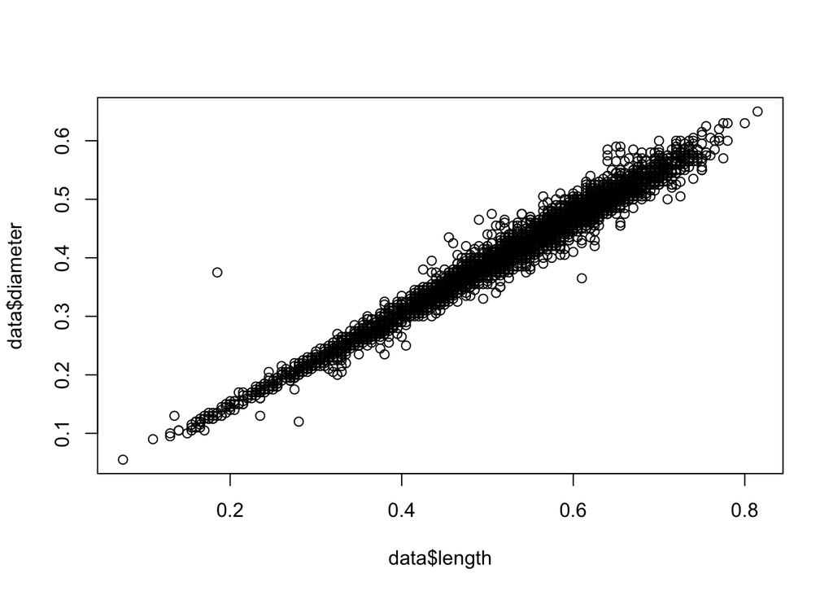

```r
# read data
data <- read.csv("http://archive.ics.uci.edu/ml/machine-learning-databases/abalone/abalone.data", header = FALSE)
names(data) <- c(
  "sex", "length", "diameter", "height", "weight.whole",
  "weight.shucked", "weight.viscera", "weight.shell", "rings"
)

data2 <- ifelse(data == "M", 1, ifelse(data == "F", 2, 3))

pchvec <- ifelse(data$gender == "M", "o", "x")
plot(data$length, data$diameter, pch = pchvec)
```

## 4.12 Testing Vector Equality

Using `==` won’t work because we are dealing with vectorization. Just like almost anything else in R, `==` is a function. The expression x == y applies the function ==() to the elements of x and y. yielding a vector of Boolean values. We can work with the vectorized nature of `==`, applying the function `all()` or we can simply use the `identical()` function.

```r
# If we want to test whether two vectors are equal, the naive approach using == won't work:
x <- 1:3
y <- c(1, 3, 4)
x == y
```

```
## [1]  TRUE FALSE FALSE
```

```r
# we could work with the vectorized nature of == using the function all():
x <- 1:3
y <- c(1, 3, 4)
x == y
```

```
## [1]  TRUE FALSE FALSE
```

```r
all(x == y)
```

```
## [1] FALSE
```

```r
identical(x,y)
```

```
## [1] FALSE
```

## 4.13 Vector Element Names

The elements of a vector can optionally be given names via the `names()` function. We can even reference elements of the vector by name.

```r
# add names
x <- c(1, 2, 4)
names(x)
```

```r
names(x) <- c("a", "b", "ab")
names(x)
```

[output not shown]

```
## [1] "a"  "b"  "ab"
```

```r
x
```

```
##  a  b ab
##  1  2  4
```

```r
# remove names
names(x) <- NULL
x
```

```
## [1] 1 2 4
```

```r
# reference elements of the vector by name:
x <- c(1, 2, 4)
names(x) <- c("a", "b", "ab")
x["b"]
```

```
## b
## 2
```

## 4.14 More on *c()*

If the arguments you pass to `c()` are of differing modes, they will be reduced to a type that is the lowest common denominator. `c()` has a flattening effect for vectors.

```r
# if the arguments you pass to c are of different modes, they will be reduced to a type that is the lowest common denominator
c(5, 2, "abc") # mixing integer and character modes, and R chooses the latter
```

```
## [1] "5"   "2"   "abc"
```

```r
c(5, 2, list(a = 1, b = 4)) # list mode here is of lower precedence
```

```
## [[1]]
## [1] 5
##
## [[2]]
## [1] 2
##
## $a
## [1] 1
##
## $b
## [1] 4
```

```r
# c has a flattening effect for vectors:
c(5, 2, c(1.5, 6)) # this just results in a single vector, not a 2-level list
```

```
## [1] 5.0 2.0 1.5 6.0
```

# 5 Matrices and Arrays

A **matrix** is a vector with two additional attributes: the number of rows and the number of columns. Since matrices are vectors, they also have modes, such as numeric and character. (On the other hand, vectors are not one-column or one-row matrices.). Matrices are special cases of a more general R type of object: **arrays**. Arrays can be multidimensional. For example, a three-dimensional array would consist of rows, columns, and layers, not just rows and columns as in the matrix case. Much of R’s power comes from the various operations you can perform on matrices.

## 5.1 Creating Matrices

Matrix row and column subscripts begin with 1. The internal storage of a matrix is in column-major order, meaning that first all of column 1 is stored, then all of column 2, and so on. The fact that R uses column-major order then determines where these four numbers are put within the matrix. We do need to warn R ahead of time that y will be a matrix and give the number of rows and columns. Though internal storage of a matrix is in column-major order, you can set the byrow argument in matrix() to true to indicate that the data is coming in row-major order.

```r
y <- matrix(c(1, 2, 3, 4), nrow = 2, ncol = 2)
y
```

```
##      [,1] [,2]
## [1,]    1    3
## [2,]    2    4
```

```r
m <- matrix(c(1, 2, 3, 4, 5, 6), nrow = 2, byrow = T)
m
```

```
##      [,1] [,2] [,3]
## [1,]    1    2    3
## [2,]    4    5    6
```

## 5.2 General Matrix Operations

### 5.2.1 Performing Linear Algebra Operations on Matrices

You can perform various linear algebra operations on matrices, such as matrix multiplication, matrix scalar multiplication, and matrix addition.

```r
y %*% y # mathematical matrix multiplication
```

```
##      [,1] [,2]
## [1,]    7   15
## [2,]   10   22
```

```r
3 * y # mathematical multiplication of matrix by scalar
```

```
##      [,1] [,2]
## [1,]    3    9
## [2,]    6   12
```

```r
y + y # mathematical matrix addition
```

```
##      [,1] [,2]
## [1,]    2    6
## [2,]    4    8
```

### 5.2.2 Matrix indexing

Negative subscripts, used with vectors to exclude certain elements, work the same way with matrices.

```r
z <- matrix(c(1, 2, 3, 4, 1, 1, 0, 0, 1, 0, 1, 0), nrow = 4, ncol = 3)
z
```

```
##      [,1] [,2] [,3]
## [1,]    1    1    1
## [2,]    2    1    0
## [3,]    3    0    1
## [4,]    4    0    0
```

```r
y <- matrix(c(11, 21, 31, 12, 22, 32), nrow = 3, ncol = 2)
y
```

```
##      [,1] [,2]
## [1,]   11   12
## [2,]   21   22
## [3,]   31   32
```

```r
# extracting cols
z[, 2:3]
```

```
##      [,1] [,2]
## [1,]    1    1
## [2,]    1    0
## [3,]    0    1
## [4,]    0    0
```

```r
# extracting rows
y[2:3, ]
```

```
##      [,1] [,2]
## [1,]   21   22
## [2,]   31   32
```

```r
# assigning values to submatrices
y[c(1, 3), ] <- matrix(c(1, 1, 8, 12), nrow = 2)
y
```

```
##      [,1] [,2]
## [1,]    1    8
## [2,]   21   22
## [3,]    1   12
```

```r
# negative subscripts
y[-2, ]
```

```
##      [,1] [,2]
## [1,]    1    8
## [2,]    1   12
```

### 5.2.3 Filtering on Matrices

Filtering can be done with matrices, just as with vectors. The filtering criterion can be based on a variable separate from the one to which the filtering will be applied.

```r
x <- matrix(c(1, 2, 3, 2, 3, 4), nrow = 3, ncol = 2)
x
```

```
##      [,1] [,2]
## [1,]    1    2
## [2,]    2    3
## [3,]    3    4
```

```r
x[x[, 2] >= 3, ]
```

```
##      [,1] [,2]
## [1,]    2    3
## [2,]    3    4
```

```r
z <- c(5, 12, 13)
x[z %% 2 == 1, ]
```

```
##      [,1] [,2]
## [1,]    1    2
## [2,]    3    4
```

## 5.3 Applying Functions to Matrix Rows and Columns

One of the most famous and most used features of R is the `*apply()` family of functions, such as `apply()`, `tapply()`, and `lapply()`. Here, we’ll look at `apply()`, which instructs R to call a user-specified function on each of the rows or each of the columns of a matrix.

### 5.3.1 Using the `apply()` Function

This is the general form of apply for matrices:

`apply(m, dimcode, f, fargs)`

where the arguments are as follows:

- `m` is the matrix.
- `dimcode` is the dimension, equal to **1** if the function applies to **rows** or **2** for **columns**.
- `f` is the function to be applied.
- `fargs` is an optional set of arguments to be supplied to `f`.

A function you write yourself is just as legitimate for use in `apply()` as any R built-in function such as `mean()`. If the function to be applied returns a vector of *k* components, then the result of `apply()` will have *k* rows. You can use the matrix **transpose** function `t()` to change it if necessary. If the function returns a scalar (which we know is just a one-element vector), the final result will be a vector, not a matrix. The function to be applied needs to take at least one argument. The formal argument here will correspond to an actual argument of one row or column in the matrix, as described previously. In some cases, you will need additional arguments for this function, which you can place following the function name in your call to `apply()`.

Contrary to common opinion, using `apply()` will generally not speed up your code. The benefits are that it makes for very compact code, which may be easier to read and modify, and you avoid possible bugs in writing code for looping. Moreover, as R moves closer and closer to parallel processing, functions like `apply()` will become more and more important.

```r
z <- matrix(c(1, 2, 3, 4, 5, 6), nrow = 3, ncol = 2)
z
```

```
##      [,1] [,2]
## [1,]    1    4
## [2,]    2    5
## [3,]    3    6
```

```r
apply(z, 2, mean)
```

```
## [1] 2 5
```

```r
# with a function
f <- function(x) x / c(2, 8)
y <- apply(z, 1, f)
y
```

```
##      [,1]  [,2] [,3]
## [1,]  0.5 1.000 1.50
## [2,]  0.5 0.625 0.75
```

```r
t(y)
```

```
##      [,1]  [,2]
## [1,]  0.5 0.500
## [2,]  1.0 0.625
## [3,]  1.5 0.750
```

## 5.4 Adding and Deleting Matrix Rows and Columns

Technically, matrices are of fixed length and dimensions, so we cannot add or delete rows or columns. However, matrices can be reassigned, and thus we can achieve the same effect as if we had directly done additions or deletions.

### 5.4.1 Changing the Size of a Matrix

The `rbind()` (row bind) and `cbind()` (column bind) functions let you add rows or columns to a matrix. Be careful with `rbind` and `cbin()`, though. Like creating a vector, creating a matrix is time consuming (matrices are vectors, after all).

```r
one <- c(1, 1, 1, 1)
z <- matrix(c(1, 1, 1, 1, 1, 2, 3, 4, 1, 1, 0, 0, 1, 0, 1, 0), nrow = 4, ncol = 4)
z
```

```
##      [,1] [,2] [,3] [,4]
## [1,]    1    1    1    1
## [2,]    1    2    1    0
## [3,]    1    3    0    1
## [4,]    1    4    0    0
```

```r
z <- cbind(one, z)
cbind(1, z)
```

```
##        one
## [1,] 1   1 1 1 1 1
## [2,] 1   1 1 2 1 0
## [3,] 1   1 1 3 0 1
## [4,] 1   1 1 4 0 0
```

```r
q <- cbind(c(1,2),c(3,4))
q
```

```
##      [,1] [,2]
## [1,]    1    3
## [2,]    2    4
```

## 5.5 More on the Vector/Matrix Distinction

```r
z <- matrix(1:8, nrow = 4)
z
```

```
##      [,1] [,2]
## [1,]    1    5
## [2,]    2    6
## [3,]    3    7
## [4,]    4    8
```

```r
length(z)
```

```
## [1] 8
```

```r
class(z)
```

```
## [1] "matrix" "array"
```

```r
attributes(z)
```

```
## $dim
## [1] 4 2
```

```r
# or
dim(z)
```

```
## [1] 4 2
```

```r
nrow(z)
```

```
## [1] 4
```

```r
ncol(z)
```

```
## [1] 2
```

## 5.6 Avoiding Unintended Dimension Reduction

In the world of statistics, dimension reduction is a good thing, with many statistical procedures aimed to do it well. If we are working with, say, 10 variables and can reduce that number to 3 that still capture the essence of our data, we’re happy. However, in R, something else might merit the name dimension reduction that we may sometimes wish to avoid. This seems innocuous, but note the format in which R has displayed r. It’s a vector format, not a matrix format. In other words, r is a vector of length 2, rather than a 1-by-2 matrix. This seems natural, but in many cases, it will cause trouble in programs that do a lot of matrix operations. You may find that your code works fine in general but fails in a special case. For instance, suppose that your code extracts a submatrix from a given matrix and then does some matrix operations on the submatrix. If the submatrix has only one row, R will make it a vector, which could ruin your computation. Fortunately, R has a way to suppress this dimension reduction: the `drop` argument. If you have a vector that you wish to be treated as a matrix, you can use the `as.matrix()`.

```r
z <- matrix(c(1, 2, 3, 4, 5, 6, 7, 8), nrow = 4, ncol = 2)
z
```

```
##      [,1] [,2]
## [1,]    1    5
## [2,]    2    6
## [3,]    3    7
## [4,]    4    8
```

```r
r <- z[2, ]
r
```

```
## [1] 2 6
```

```r
attributes(z)
```

```
## $dim
## [1] 4 2
```

```r
attributes(r)
```

[output not shown]

```r
str(z)
```

```
##  num [1:4, 1:2] 1 2 3 4 5 6 7 8
```

```r
str(r)
```

```
##  num [1:2] 2 6
```

```r
# suppressing dimension reduction
r <- z[2, , drop = FALSE]
r
```

```
##      [,1] [,2]
## [1,]    2    6
```

```r
dim(r)
```

```
## [1] 1 2
```

## 5.7 Naming Matrix Rows and Columns

The natural way to refer to rows and columns in a matrix is via the row and column numbers. However, you can also give names to these entities. The function `rownames()` works similarly. Naming rows and columns is usually less important when writing R code for general applications, but it can be useful when analyzing a specific data set.

```r
z <- matrix(c(1, 2, 3, 4), nrow = 2, ncol = 2)
z
```

```
##      [,1] [,2]
## [1,]    1    3
## [2,]    2    4
```

```r
colnames(z) <- c("a", "b")
z
```

```
##      a b
## [1,] 1 3
## [2,] 2 4
```

## 5.8 Higher-Dimensional Arrays

In a statistical context, a typical matrix in R has rows corresponding to observations, say on various people, and columns corresponding to variables, such as weight and blood pressure. The matrix is then a two-dimensional data structure. But suppose we also have data taken at different times, one data point per person per variable per time. Time then becomes the third dimension, in addition to rows and columns. In R, such data sets are called arrays. In the argument `dim=c(3,2,2)`, we are specifying two layers (this is the second 2), each consisting of three rows and two columns. This then becomes an attribute of the data structure. Each element of tests now has three subscripts, rather than two as in the matrix case. The first subscript corresponds to the first element in the $dim vector, the second subscript corresponds to the second element in the vector, and so on.

```r
firsttest <- matrix(c(46, 21, 50, 30, 25, 50), nrow = 3, ncol = 2)
secondtest <- matrix(c(46, 41, 50, 43, 35, 50), nrow = 3, ncol = 2)
# creating an array
tests <- array(data = c(firsttest, secondtest), dim = c(3, 2, 2))
tests
```

```
## , , 1
##
##      [,1] [,2]
## [1,]   46   30
## [2,]   21   25
## [3,]   50   50
##
## , , 2
##
##      [,1] [,2]
## [1,]   46   43
## [2,]   41   35
## [3,]   50   50
```

```r
attributes(tests)
```

```
## $dim
## [1] 3 2 2
```

```r
# subscripting elements in an array
tests[3, 2, 1]
```

```
## [1] 50
```

# 6 Lists

## 6.1 Creating Lists

Technically, a list is a vector. Ordinary vectors—those of the type we’ve been using so far in this book—are termed *atomic* vectors, since their components cannot be broken down into smaller components. In contrast, lists are referred to as *recursive* vectors. The component names—called *tags* in the R literature—such as `salary` are optional. Names of list components can be abbreviated to whatever extent is possible without causing ambiguity.

```r
# list with tags
j <- list(name = "Joe", salary = 55000, union = T)
j
```

```
## $name
## [1] "Joe"
##
## $salary
## [1] 55000
##
## $union
## [1] TRUE
```

```r
# list without tags
jalt <- list("Joe", 55000, T)
jalt
```

```
## [[1]]
## [1] "Joe"
##
## [[2]]
## [1] 55000
##
## [[3]]
## [1] TRUE
```

```r
j$salary
```

```
## [1] 55000
```

## 6.2 General List Operations

### 6.2.1 List Indexing

You can access a list component in several different ways. We can refer to list components by their numerical indices, treating the list as a vector. So, there are three ways to access an individual component c of a list lst and _return it in the data type of c__. An alternative is to use single brackets rather than double brackets. Both single-bracket and double-bracket indexing access list elements in vector-index fashion. But there is an important difference from ordinary (atomic) vector indexing. If single brackets [ ] are used, the result is another list—a sublist of the original. The subsetting operation returned another list consisting of the x components of the original list j. Note that the word returned makes sense here, since **index brackets are functions**. By contrast, you can use double brackets [[ ]] for referencing only a single component, with the result having the type of that component.

```r
j$salary
```

```
## [1] 55000
```

```r
j[["salary"]]
```

```
## [1] 55000
```

```r
j[[2]]
```

```
## [1] 55000
```

```r
# double brackets
j$salary
```

```
## [1] 55000
```

```r
j[["salary"]]
```

```
## [1] 55000
```

```r
j[[2]]
```

```
## [1] 55000
```

```r
# single brackets
j["salary"]
```

```
## $salary
## [1] 55000
```

```r
j[2]
```

```
## $salary
## [1] 55000
```

```r
j[1:2]
```

```
## $name
## [1] "Joe"
##
## $salary
## [1] 55000
```

```r
j2 <- j[2]
j2 # returns the result in the form of a list
```

```
## $salary
## [1] 55000
```

```r
class(j2)
```

```
## [1] "list"
```

```r
j2a <- j[[2]]
j2a # works since we are only accessing a single element
```

```
## [1] 55000
```

```r
class(j2a)
```

```
## [1] "numeric"
```

```r
str(j2)
```

```
## List of 1
##  $ salary: num 55000
```

### 6.2.2 Adding and Deleting List Elements

The operations of adding and deleting list elements arise in a surprising number of contexts. This is especially true for data structures in which lists form the foundation, such as data frames and R classes. **New components can be added** after a list is created. Adding components can also be done via a vector index. You can **delete** a list component by setting it to NULL. You can also **concatenate** lists. Since a list is a vector, you can obtain the number of components in a list via `length()`.

```r
z <- list(a = "abc", b = 12)
z
```

```
## $a
## [1] "abc"
##
## $b
## [1] 12
```

```r
# adding components
z$c <- "sailing"
z
```

```
## $a
## [1] "abc"
##
## $b
## [1] 12
##
## $c
## [1] "sailing"
```

```r
# adding components via vector indexing
z[[4]] <- 28
z[5:7] <- c(FALSE, TRUE, TRUE)
z
```

```
## $a
## [1] "abc"
##
## $b
## [1] 12
##
## $c
## [1] "sailing"
##
## [[4]]
## [1] 28
##
## [[5]]
## [1] FALSE
##
## [[6]]
## [1] TRUE
##
## [[7]]
## [1] TRUE
```

```r
# deleting elements
z$b <- NULL
z
```

```
## $a
## [1] "abc"
##
## $c
## [1] "sailing"
##
## [[3]]
## [1] 28
##
## [[4]]
## [1] FALSE
##
## [[5]]
## [1] TRUE
##
## [[6]]
## [1] TRUE
```

```r
# concatenating lists
c(list("Joe", 55000, T), list(5))
```

```
## [[1]]
## [1] "Joe"
##
## [[2]]
## [1] 55000
##
## [[3]]
## [1] TRUE
##
## [[4]]
## [1] 5
```

```r
length(j)
```

```
## [1] 3
```

## 6.3 Accessing List Components and Values

If the components in a list do have tags, you can obtain them via `names()`. To obtain the values, use `unlist()`. The return value of unlist() is a vector. We can remove lksit names by setting their them to NULL or with with `unname()`.

```r
# getting components tags
names(j)
```

```
## [1] "name"   "salary" "union"
```

```r
# getting values
# character strings
ulj <- unlist(j)
class(ulj)
```

```
## [1] "character"
```

```r
ulj
```

```
##    name  salary   union
##   "Joe" "55000"  "TRUE"
```

```r
# numeric vector
z <- list(a = 5, b = 12, c = 13)
y <- unlist(z)
class(y)
```

```
## [1] "numeric"
```

```r
y
```

```
##  a  b  c
##  5 12 13
```

```r
# mixed = output -> the least common denominator: character strings
w <- list(a = 5, b = "xyz")
wu <- unlist(w)
class(wu)
```

```
## [1] "character"
```

```r
wu
```

```
##     a     b
##   "5" "xyz"
```

```r
# removing names
names(wu) <- NULL
wu
```

```
## [1] "5"   "xyz"
```

```r
# we can also remove the elements' names directly with unname:
wun <- unname(wu)
wun
```

```
## [1] "5"   "xyz"
```

## 6.4 Applying Functions to Lists

Two functions are handy for applying functions to lists: lapply and sapply.

### 6.4.1 Using the *lapply()* and *sapply()* Functions

The function `lapply()` (for list apply) works calling the specified function on each component of a list (or vector coerced to a list) and returning another list. In some cases, such as the example here, the list returned by `lapply()` could be simplified to a vector or matrix. This is exactly what `sapply()` (for simplified [l]apply) does. The concatenate function `c()` has an optional argument recursive, which controls whether *flattening* occurs when recursive lists are combined.

```r
lapply(list(1:3, 25:29), median)
```

```
## [[1]]
## [1] 2
##
## [[2]]
## [1] 27
```

```r
sapply(list(1:3,25:29),median)
```

```
## [1]  2 27
```

## 6.5 Recursive Lists

Lists can be recursive, meaning that you can have lists within lists.

```r
b <- list(u = 5, v = 12)
c <- list(w = 13)
a <- list(b, c)
a
```

```
## [[1]]
## [[1]]$u
## [1] 5
##
## [[1]]$v
## [1] 12
##
##
## [[2]]
## [[2]]$w
## [1] 13
```

```r
length(a)
```

```
## [1] 2
```

```r
c(list(a = 1, b = 2, c = list(d = 5, e = 9)))
```

```
## $a
## [1] 1
##
## $b
## [1] 2
##
## $c
## $c$d
## [1] 5
##
## $c$e
## [1] 9
```

```r
# flattening a list
c(list(a = 1, b = 2, c = list(d = 5, e = 9)), recursive = T)
```

```
##   a   b c.d c.e
##   1   2   5   9
```

# 7 Data Frames

On a technical level, a data frame is a list, with the components of that list being equal-length vectors. Actually, R does allow the components to be other types of objects, including other data frames. If the named argument stringsAsFactors is not specified, then by default, stringsAsFactors will be TRUE.

## 7.1 Creating Data Frames

```r
kids <- c("Jack", "Jill")
ages <- c(12, 10)
d <- data.frame(kids, ages, stringsAsFactors = FALSE) # produce a data frame from our two vectors: kids and ages
d
```

```
##   kids ages
## 1 Jack   12
## 2 Jill   10
```

### 7.1.1 Accessing Data Frames

Since d is a list, we can access it as such via component index values or component names. But we can treat it in a matrix-like fashion as well. This matrix-like quality is also seen when we take d apart using `str()`. Consider three ways to access the first column of our data frame above: d[[1]], d[, 1], and d$kids, but matrix-like notation d[, 1] is especially handy if you are extracting subdata frames.

```r
# accessing data frames -> vector fashion
d[[1]]
```

```
## [1] "Jack" "Jill"
```

```r
d$kids
```

```
## [1] "Jack" "Jill"
```

```r
# matrix fashion
d[, 1]
```

```
## [1] "Jack" "Jill"
```

```r
str(d)
```

```
## 'data.frame':    2 obs. of  2 variables:
##  $ kids: chr  "Jack" "Jill"
##  $ ages: num  12 10
```

```r
examsquiz <- read.table("input/ExamsQuiz.txt", header = TRUE)
examsquiz
```

```
##   MIDTERM FINAL AVG_QUIZ
## 1     2.0   3.3      4.0
## 2     3.3   2.0      3.7
## 3     4.0   4.3      4.0
## 4     2.3   0.0      3.3
## 5     2.3   1.0      3.3
## 6     3.3   3.7      4.0
```

## 7.2 Other Matrix-Like Operations

### 7.2.1 Extracting Subdata Frames

A data frame can be viewed in row-and-column terms. In particular, we can extract subdata frames by rows or columns. By specifying `drop=FALSE` we can keep them as a (one-column) data frame. We can also do filtering.

```r
# returns another data frame
examsquiz[2:5, ]
```

```
##   MIDTERM FINAL AVG_QUIZ
## 2     3.3   2.0      3.7
## 3     4.0   4.3      4.0
## 4     2.3   0.0      3.3
## 5     2.3   1.0      3.3
```

```r
# returns a vector
examsquiz[2:5, 2]
```

```
## [1] 2.0 4.3 0.0 1.0
```

```r
class(examsquiz[2:5, 2])
```

```
## [1] "numeric"
```

```r
# returns a one-column data frame
examsquiz[2:5, 2, drop = FALSE]
```

```
##   FINAL
## 2   2.0
## 3   4.3
## 4   0.0
## 5   1.0
```

```r
class(examsquiz[2:5, 2, drop = FALSE])
```

```
## [1] "data.frame"
```

```r
# filtering
examsquiz[examsquiz$MIDTERM >= 3.8, ]
```

```
##   MIDTERM FINAL AVG_QUIZ
## 3       4   4.3        4
```

### 7.2.2 More on Treatment of NA Values

In statistical analyses, R would do its best to cope with the missing data. However, in some situations, we need to set the option `na.rm=TRUE`, explicitly telling R to ignore NA values. The `subset()` function, which saves you the trouble of specifying `na.rm=TRUE`. You can apply it in data frames **for row selection**. The column names are taken in the context of the given data frame. In some cases, we may wish to rid our data frame of any observation that has at least one NA value. A handy function for this purpose is `complete.cases()`.

```r
x <- c(2, NA, 4)
mean(x)
```

```
## [1] NA
```

```r
mean(x, na.rm = TRUE)
```

```
## [1] 3
```

```r
# using subset() -> na.rm = TRUE per default
subset(examsquiz, MIDTERM >= 3.8)
```

```
##   MIDTERM FINAL AVG_QUIZ
## 3       4   4.3        4
```

```r
# getting rid of any NA's observations
kids2 <- c("Jack", NA, "Jillian", "John")
states <- c("CA", "MA", "MA", NA)
d4 <- data.frame(kids2, states, stringsAsFactors = FALSE)
complete.cases(d4)
```

```
## [1]  TRUE FALSE  TRUE FALSE
```

```r
d5 <- d4[complete.cases(d4), ]
d5
```

```
##     kids2 states
## 1    Jack     CA
## 3 Jillian     MA
```

### 7.2.3 Using the *rbind()* and *cbind()* Functions and Alternatives

The `rbind()` and `cbind()` matrix functions work with data frames, too, providing that you have compatible sizes, of course. For instance, you can use `cbind()` to add a new column that has the same length as the existing columns. In using `rbind()` to add a row, the added row is typically in the form of another data frame or list. You can also create new columns from old ones. We can even exploit recycling to add a column that is of a different length than those in the data frame.

```r
kids3 <- c("Jack", "Jill")
ages <- c(12, 10)
d <- data.frame(kids3, ages, stringsAsFactors = FALSE)
d
```

```
##   kids3 ages
## 1  Jack   12
## 2  Jill   10
```

```r
# adding rows
d <- rbind(d, list("Laura", 19))
d
```

```
##   kids3 ages
## 1  Jack   12
## 2  Jill   10
## 3 Laura   19
```

```r
# creating new columns from old ones
eq <- cbind(examsquiz, examsquiz$FINAL - examsquiz$MIDTERM)
class(eq)
```

```
## [1] "data.frame"
```

```r
eq
```

```
##   MIDTERM FINAL AVG_QUIZ examsquiz$FINAL - examsquiz$MIDTERM
## 1     2.0   3.3      4.0                                 1.3
## 2     3.3   2.0      3.7                                -1.3
## 3     4.0   4.3      4.0                                 0.3
## 4     2.3   0.0      3.3                                -2.3
## 5     2.3   1.0      3.3                                -1.3
## 6     3.3   3.7      4.0                                 0.4
```

```r
# better solution
examsquiz$ExamDiff <- examsquiz$FINAL - examsquiz$MIDTERM
examsquiz
```

```
##   MIDTERM FINAL AVG_QUIZ ExamDiff
## 1     2.0   3.3      4.0      1.3
## 2     3.3   2.0      3.7     -1.3
## 3     4.0   4.3      4.0      0.3
## 4     2.3   0.0      3.3     -2.3
## 5     2.3   1.0      3.3     -1.3
## 6     3.3   3.7      4.0      0.4
```

```r
# adding cols with recycling
d$one <- 1
d
```

```
##   kids3 ages one
## 1  Jack   12   1
## 2  Jill   10   1
## 3 Laura   19   1
```

### 7.2.4 Applying *apply()*

You can use `apply()` on data frames, if the columns are all of the same type.

```r
apply(examsquiz, 1, max)
```

```
## [1] 4.0 3.7 4.3 3.3 3.3 4.0
```

## 7.3 Merging Data Frames

In the relational database world, one of the most important operations is that of a join, in which two tables can be combined according to the values of a common variable. In R, two data frames can be similarly combined using the `merge()` function. The `merge()` function has named arguments `by.x` and `by.y`, which handle cases in which variables have similar information but different names in the two data frames, so you must choose matching variables with great care.

```r
kids.names <- c("Jack", "Jill", "Jillian", "John")
kids.states <- c("CA", "MA", "MA", "HI")
d1 <- data.frame(kids.names, kids.states, stringsAsFactors = FALSE)
kids.names <- c("Jill", "Lillian", "Jack")
kids.ages <- c(10, 7, 12)
d2 <- data.frame(kids.names, kids.ages, stringsAsFactors = FALSE)
d <- merge(d1, d2)
```

## 7.4 Applying Functions to Data Frames

As with lists, you can use the `lapply` and `sapply` functions with data frames.

### 7.4.1 Using *lapply()* and *sapply()* on Data Frames

Data frames are special cases of lists, with the list components consisting of the data frame’s columns. Thus, if you call `lapply()` on a data frame with a specified function `f()`, then `f()` will be called on each of the frame’s columns, with the return values placed in a list. We could coerce a list to a data frame with `as.data.frame()`.

```r
dl <- lapply(d2, sort)
dl
```

```
## $kids.names
## [1] "Jack"    "Jill"    "Lillian"
##
## $kids.ages
## [1]  7 10 12
```

```r
as.data.frame(dl)
```

```
##   kids.names kids.ages
## 1       Jack         7
## 2       Jill        10
## 3    Lillian        12
```

# 8 Factors and Tables

## 8.1 Factors and Levels

An R factor might be viewed simply as a vector with a bit more information added. That extra information consists of a record of the distinct values in that vector, called *levels*. The core of *xf* here is not (5,12,13,12) but rather (1,2,3,2). The latter means that our data consists first of a level-1 value, then level-2 and level-3 values, and finally another level-2 value. So the data has been recoded by level. The levels themselves are recorded too, of course, though as characters such as “5” rather than 5. The length of a factor is still defined in terms of the length of the data rather than being a count of the number of levels. We can anticipate future new levels.

```r
x <- c(5, 12, 13, 12)
xf <- factor(x)
xf
```

```
## [1] 5  12 13 12
## Levels: 5 12 13
```

```r
str(xf)
```

```
##  Factor w/ 3 levels "5","12","13": 1 2 3 2
```

```r
unclass(xf)
```

```
## [1] 1 2 3 2
## attr(,"levels")
## [1] "5"  "12" "13"
```

```r
length(xf)
```

```
## [1] 4
```

```r
# anticipating levels
xff <- factor(x, levels = c(5, 12, 13, 88))
xff
```

```
## [1] 5  12 13 12
## Levels: 5 12 13 88
```

```r
xff[2] <- 88
xff
```

```
## [1] 5  88 13 12
## Levels: 5 12 13 88
```

## 8.2 Common Functions Used with Factors

With factors, we have yet another member of the family of apply functions, `tapply`, as well as two other functions commonly used with factors: `split()` and `by()`.

### 8.2.1 The *tapply()* Function

As motivation, suppose we have a vector x of ages of voters and a factor f showing some nonumeric trait of those voters, such as party affiliation (Democrat, Republican, Unaffiliated). We might wish to find the mean ages in x within each of the party groups. In typical usage, the call `tapply(x,f,g)` has x as a vector, f as a factor or list of factors, and g as a function. The function g() in our little example above would be R’s built-in mean() function. If we wanted to group by both party and another factor, say gender, we would need f to consist of the two factors, party and gender. Each factor in f must have the same length as x. If a component of f is a vector, it will be coerced into a factor by applying `as.factor()` to it. The operation performed by tapply() is to (temporarily) split x into groups, each group corresponding to a level of the factor (or a combination of levels of the factors in the case of multiple factors), and then apply g() to the resulting subvectors of x.

```r
ages <- c(25, 26, 55, 37, 21, 42)
affils <- c("R", "D", "D", "R", "U", "D")
tapply(ages, affils, mean)
```

```
##  D  R  U
## 41 31 21
```

```r
# with two or more factors
d <- data.frame(list(gender = c("M", "M", "F", "M", "F", "F"), age = c(47, 59, 21, 32, 33, 24), income = c(55000, 88000, 32450, 76500, 123000, 45650)))
d
```

```
##   gender age income
## 1      M  47  55000
## 2      M  59  88000
## 3      F  21  32450
## 4      M  32  76500
## 5      F  33 123000
## 6      F  24  45650
```

```r
d$over25 <- ifelse(d$age > 25, 1, 0)
d
```

```
##   gender age income over25
## 1      M  47  55000      1
## 2      M  59  88000      1
## 3      F  21  32450      0
## 4      M  32  76500      1
## 5      F  33 123000      1
## 6      F  24  45650      0
```

```r
tapply(d$income, list(d$gender, d$over25), mean)
```

```
##       0         1
## F 39050 123000.00
## M    NA  73166.67
```

### 8.2.2 The *split()* Function

In contrast to `tapply()`, which splits a vector into groups and then applies a specified function on each group, `split()` stops at that first stage, just forming the groups. The basic form, without bells and whistles, is split(x,f), with x being a vector or data frame and f being a factor or a list of factors which are returned in a list. **x is allowed to be a data frame with split() but not with tapply()**.

```r
split(d$income, list(d$gender, d$over25))
```

```
## $F.0
## [1] 32450 45650
##
## $M.0
## numeric(0)
##
## $F.1
## [1] 123000
##
## $M.1
## [1] 55000 88000 76500
```

```r
# determine the indices of the vector elements corresponding to male, female, and infant
g <- c("M", "F", "F", "I", "M", "M", "F")
split(1:7, g)
```

```
## $F
## [1] 2 3 7
##
## $I
## [1] 4
##
## $M
## [1] 1 5 6
```

### 8.2.3 The *by()* Function

Suppose in the abalone example we wish to do regression analyses of diameter against length separately for each gender code: males, females, and infants. At first, this seems like something tailor-made for `tapply()`, but the first argument of that function must be a vector, not a matrix or a data frame. Yet the input for regression is a matrix (or data frame) with at least two columns: one for the predicted variable and one or more for predictor variables. In our datalone data application, the matrix would consist of a column for the diameter data and a column for length. The `by()` function can be used here. It works like `tapply()` (which it calls internally, in fact), but it is applied to objects rather than vectors. Calls to `by()` look very similar to calls to `tapply()`, with the first argument specifying our data, the second the grouping factor, and the third the function to be applied to each group. Just as `tapply()` forms groups of indices of a vector according to levels of a factor, this `by()` call finds groups of row numbers of the data frame data That creates three subdata frames: one for each gender level of M, F, and I. The anonymous function we defined regresses the second column of its matrix argument m against the third column. This function will be called three times—once for each of the three subdata frames created earlier— thus producing the three regression analyses.

```r
by(data, data$sex, function(m) lm(m[, 2] ~ m[, 3]))
```

```
## data$sex: F
##
## Call:
## lm(formula = m[, 2] ~ m[, 3])
##
## Coefficients:
## (Intercept)       m[, 3]
##     0.04288      1.17918
##
## ------------------------------------------------------------
## data$sex: I
##
## Call:
## lm(formula = m[, 2] ~ m[, 3])
##
## Coefficients:
## (Intercept)       m[, 3]
##     0.02997      1.21833
##
## ------------------------------------------------------------
## data$sex: M
##
## Call:
## lm(formula = m[, 2] ~ m[, 3])
##
## Coefficients:
## (Intercept)       m[, 3]
##     0.03653      1.19480
```

## 8.3 Working with Tables

The `table()` function creates contingency tables correctly. The first argument in a call to `table()` is either a factor or a list of factors. The two factors here were (5,12,13,12,13,5,13) and (“a”,“bc”,“a”,“a”,“bc”, “a”,“a”). Typically a data frame serves as the `table()` data argument. We can also get one-dimensional counts with `table()`, which are counts on a single factor

```r
u <- c(22, 8, 33, 6, 8, 29, -2)
fl <- list(c(5, 12, 13, 12, 13, 5, 13), c("a", "bc", "a", "a", "bc", "a", "a"))

# creating a contingency table
tapply(u, fl, length)
```

```
##    a bc
## 5  2 NA
## 12 1  1
## 13 2  1
```

```r
# or (better!)
table(fl)
```

```
##     fl.2
## fl.1 a bc
##   5  2  0
##   12 1  1
##   13 2  1
```

```r
# getting one-dimensional count
table(c(5, 12, 13, 12, 8, 5))
```

```
##
##  5  8 12 13
##  2  1  2  1
```

```r
# another contingency table example
ct <- read.table("input/ct.tsv", header = T)
ct
```

```
##   Vote.for.X Voted.For.X.Last.Time
## 1        Yes                   Yes
## 2        Yes                    No
## 3         No                    No
## 4   Not Sure                   Yes
## 5         No                    No
```

```r
cttab <- table(ct)
cttab
```

```
##           Voted.For.X.Last.Time
## Vote.for.X No Yes
##   No        2   0
##   Not Sure  0   1
##   Yes       1   1
```

### 8.3.1 Matrix/Array-Like Operations on Tables

Just as most (nonmathematical) matrix/array operations can be used on data frames, they can be applied to tables, too. We can access the table cell counts using matrix notation. In statistics, the marginal values of a variable are those obtained when this variable is held constant while others are summed. We can of course obtain these via the matrix `apply()` function, but R supplies a function `addmargins()` for this purpose. We can get the names of the dimensions and levels through `dimnames()`.

The function `subtable()` (deprecated) performs **subtable extraction**. It has two arguments: - `tbl`: The table of interest, of class “table”. - `subnames`: A list specifying the desired subtable extraction. Each component of this list is named after some dimension of tbl, and the value of that component is a vector of the names of the desired levels.

It can be difficult to view a table that is very big, with a large number of rows or dimensions. One approach might be to focus on the cells with the largest frequencies. That’s the purpose of the `tabdom()` function developed below— **it reports the dominant frequencies in a table**.

```r
class(cttab)
```

```
## [1] "table"
```

```r
cttab[1, 1]
```

```
## [1] 2
```

```r
cttab[1, ]
```

```
##  No Yes
##   2   0
```

```r
# change cell counts to proportions
cttab / 5
```

```
##           Voted.For.X.Last.Time
## Vote.for.X  No Yes
##   No       0.4 0.0
##   Not Sure 0.0 0.2
##   Yes      0.2 0.2
```

```r
# in pct
cttab / 5 * 100
```

```
##           Voted.For.X.Last.Time
## Vote.for.X No Yes
##   No       40   0
##   Not Sure  0  20
##   Yes      20  20
```

```r
# getting marginal totals
apply(cttab, 1, sum)
```

```
##       No Not Sure      Yes
##        2        1        2
```

```r
addmargins(cttab)
```

```
##           Voted.For.X.Last.Time
## Vote.for.X No Yes Sum
##   No        2   0   2
##   Not Sure  0   1   1
##   Yes       1   1   2
##   Sum       3   2   5
```

```r
# getting names of the dimensions and levels
dimnames(cttab)
```

```
## $Vote.for.X
## [1] "No"       "Not Sure" "Yes"
##
## $Voted.For.X.Last.Time
## [1] "No"  "Yes"
```

```r
# extracting a subtable
subtable <- function(tbl, subnames) {
  tblarray <- unclass(tbl)
  dcargs <- list(tblarray)
  ndims <- length(subnames)
  for (i in 1:ndims) {
    dcargs[[i + 1]] <- subnames[[i]]
  }
  subarray <- do.call("[", dcargs)
  dims <- lapply(subnames, length)
  subtbl <- array(subarray, dims, dimnames = subnames)
  class(subtbl) <- "table"
  return(subtbl)
}
subtable(cttab, list(Vote.for.X = c("No", "Yes"), Voted.for.X.Last.Time = c("No", "Yes")))
```

```
##           Voted.for.X.Last.Time
## Vote.for.X No Yes
##        No   2   0
##        Yes  1   1
```

```r
# focusing on the cells with the largest frequencies
# finds the cells in table tbl with the k highest frequencies; handling of ties is unrefined
tabdom <- function(tbl, k) {
  tbldf <- as.data.frame(tbl)
  freqord <- order(tbldf$Freq, decreasing = TRUE)
  dom <- tbldf[freqord, ][1:k, ]
  return(dom)
}

d <- c(5, 12, 13, 4, 3, 28, 12, 12, 9, 5, 5, 13, 5, 4, 12)
dtab <- table(d)
tabdom(dtab, 3)
```

```
##    d Freq
## 3  5    4
## 5 12    4
## 2  4    2
```

```r
tabdom(cttab, 2)
```

```
##   Vote.for.X Voted.For.X.Last.Time Freq
## 1         No                    No    2
## 3        Yes                    No    1
```

## 8.4 Other Factor- and Table-Related Functions

R includes a number of other functions that are handy for working with tables and factors. We’ll discuss two of them here: `aggregate()` and `cut()`.

### 8.4.1 The *aggregate()* Function

The `aggregate()` function calls `tapply()` once for each variable in a group. The first argument, aba[,-1], is the entire data frame except for the first column, which is Gender itself. The second argument, which must be a list, is our Gender factor as before. Finally, the third argument tells R to compute the median on each column in each of the data frames generated by the subgrouping corresponding to our factors. There are three such subgroups in our example here and thus three rows in the output of `aggregate()`.

```r
aggregate(data[, -1], list(data$sex), median)
```

```
##   Group.1 length diameter height weight.whole weight.shucked weight.viscera
## 1       F  0.590    0.465  0.160      1.03850        0.44050         0.2240
## 2       I  0.435    0.335  0.110      0.38400        0.16975         0.0805
## 3       M  0.580    0.455  0.155      0.97575        0.42175         0.2100
##   weight.shell rings
## 1        0.295    10
## 2        0.113     8
## 3        0.276    10
```

### 8.4.2 The *cut()* Function

A common way to generate factors, especially for tables, is the `cut()` function. You give it a data vector x and a set of bins defined by a vector b. The function then determines which bin each of the elements of x falls into. This returns a vector but we can convert it into a factor and possibly then use it to build a table.

```r
z <- c(0.88114802, 0.28532689, 0.58647376, 0.42851862, 0.46881514, 0.24226859, 0.05289197, 0.88035617)
binmarks <- seq(from = 0.0, to = 1.0, by = 0.1)
cut(z, binmarks, labels = F) # This says that z[1], 0.88114802, fell into bin 9, which was (0,0,0.1]; z[2], 0.28532689, fell into bin 3; and so on.
```

```
## [1] 9 3 6 5 5 3 1 9
```

# 9 R Programming Structures

Control statements in R look very similar to those of the ALGOL-descendant family languages: C, C++, Python, Perl and so on.

## 9.1 Control Statements

### 9.1.1 Loops

The syntax for loops looks like this: `for (n in x) {` It means that there will be one iteration of the loop for each component of the vector x, with n taking on the values of those components—in the first iteration, n = x[1]; in the second iteration, n = x[2]; and so on. C-style looping with while and repeat is also available, complete with break, a statement that causes control to leave the loop. `repeat` has no Boolean exit condition. You must use `break` (or something like `return()`). Of course, `break` can be used with for loops, too.

Another useful statement is `next`, which instructs the interpreter to skip the remainder of the current iteration of the loop and proceed directly to the next one. This provides a way to avoid using complexly nested if-then-else constructs, which can make the code confusing. The `for` construct works on any vector, regardless of mode.

```r
# very simple loop
x <- c(5, 12, 13)
for (n in x) print(n^2)
```

```
## [1] 25
## [1] 144
## [1] 169
```

```r
# while and repeat
i <- 1
while(i <= 10) i <- i + 4;
i
```

```
## [1] 13
```

```r
# similar
i <- 1
while(TRUE){
  i <- i + 4
  if(i > 10) break
}
i
```

```
## [1] 13
```

```r
# similar
i <- 1
repeat{
  i <- i + 4
  if(i > 10) break
}
i
```

```
## [1] 13
```

```r
sim <- function(nreps) {
  commdata <- list()
  commdata$countabsamecomm <- 0
  for (rep in 1:nreps) {
    commdata$whosleft <- 1:20
    commdata$numabchosen <- 0
    commdata <- choosecomm(commdata, 5)
    if (commdata$numabchosen > 0) next
    commdata <- choosecomm(commdata, 4)
    if (commdata$numabchosen > 0) next
    commdata <- choosecomm(commdata, 3)
  }
  print(commdata$countabsamecomm / nreps)
}

# The two next statements occur within the loop that starts at line 1325. Thus, when the if condition holds in line 1329, lines 1330 through 1332 will be skipped, and control will transfer to line 1325. The situation in line 1331 is similar.

# without using next, we would need to resort to nested if statements
sim <- function(nreps) {
  commdata <- list()
  commdata$countabsamecomm <- 0
  for (rep in 1:nreps) {
    commdata$whosleft <- 1:20
    commdata$numabchosen <- 0
    commdata <- choosecomm(commdata, 5)
    if (commdata$numabchosen == 0) {
      commdata <- choosecomm(commdata, 4)
      if (commdata$numabchosen == 0) {
        commdata <- choosecomm(commdata, 3)
      }
    }
  }
  print(commdata$countabsamecomm / nreps)
}
```

### 9.1.2 Looping Over Nonvector Sets

**R does not directly support iteration over nonvector sets**, but there are a couple of indirect yet easy ways to accomplish it:

- Use `lapply()`, assuming that the iterations of the loop are independent of each other, thus allowing them to be performed in any order.
- Use `get()`. As its name implies, this function takes as an argument a character string representing the name of some object and returns the object of that name. It sounds simple, but `get()` is a very powerful function.

```r
# applying lm() to two matrices
u <- matrix(c(1, 2, 3, 1, 2, 4), nrow = 3, ncol = 2)
v <- matrix(c(8, 12, 20, 15, 10, 2), nrow = 3, ncol = 2)
for (m in c("u", "v")) {
  z <- get(m)
  print(lm(z[, 2] ~ z[, 1]))
}
```

```
##
## Call:
## lm(formula = z[, 2] ~ z[, 1])
##
## Coefficients:
## (Intercept)       z[, 1]
##     -0.6667       1.5000
##
##
## Call:
## lm(formula = z[, 2] ~ z[, 1])
##
## Coefficients:
## (Intercept)       z[, 1]
##      23.286       -1.071
```

### 9.1.3 *if-else*

The syntax looks like this: `if (r == 4) { x <- 1 } else { x <- 3 y <- 4 }` The if section consists of just a single statement but the braces around that statement are necessary because the right brace before the else is used by the R parser to deduce that this is an if-else rather than just an if. An if-else statement works as a function call, and as such, it returns the last value assigned. When working with vectors, use the `ifelse()` function as it will likely produce faster code.

```r
x <- 2
y <- if (x == 2) x else x + 1
y
```

```
## [1] 2
```

```r
x <- 3
y <- if (x == 2) x else x + 1
y
```

```
## [1] 4
```

## 9.3 Default Values for Arguments

If we don’t want the default value of a given function, we must name the argument in our call. Hence the terminology *named argument*. In the followed example `header = TRUE` would be the named argument.

```r
# testscores <- read.table("exams", header = TRUE)
```

## 9.4 Return Values

The return value of a function can be any R object. Although the return value is often a list, it could even be another function. You can transmit a value back to the caller by explicitly calling `return()`. Without this call, the value of the last executed statement will be returned by default.

```r
oddcount <- function(x) {
  k <- 0 # assign 0 to k
  for (n in x) {
    if (n %% 2 == 1) k <- k + 1 # %% is the modulo operator
  }
  return(k)
}

# on the other hand (returning k as our last statement)
oddcount2 <- function(x) {
  k <- 0 # assign 0 to k
  for (n in x) {
    if (n %% 2 == 1) k <- k + 1 # %% is the modulo operator
  }
  k
}
```

### 9.4.1 Deciding Whether to Explicitly Call *return()*

The prevailing R idiom is to avoid explicit calls to `return()`. One of the reasons cited for this approach is that calling that function lengthens execution time. However, unless the function is very short, the time saved is negligible, so this might not be the most compelling reason to refrain from using `return()`. But it usually isn’t needed nonetheless.

Good software design, however, should be mean that you can glance through a function’s code and immediately spot the various points at which control is returned to the caller. The easiest way to accomplish this is to use an explicit `return()` call in all lines in the middle of the code that cause a return. (You can still omit a `return()` call at the end of the function if you wish.)

### 9.4.2 Returning Complex Objects

Since the return value can be any R object, you can return complex objects. If your function has multiple return values, place them in a list or other container.

```r
g <- function() {
  t <- function(x) {
    return(x^2)
  }
  return(t)
}
g()
```

```
## function(x) {
##     return(x^2)
##   }
## <environment: 0x7f9fa02fddd0>
```

## 9.5 Functions Are Objects

R functions are *first-class objects* (of the class “function”, of course), meaning that they can be used for the most part just like other objects. Even the “{” is a function. Arguments to function() can later be accessed via the R functions `formals()` and `body()`. Using R in interactive mode, simply typing the name of an object results in printing that object to the screen. Functions are no exception, since they are objects just like anything else. If you wish to view a lengthy function in this way, run it through `page()`. Some of R’s most fundamental built-in functions are written directly in C, and thus they are not viewable in this manner.

Since functions are objects, you can also assign them, use them as arguments to other functions, and so on. And since functions are objects, you can loop through a list consisting of several functions. This would be useful, for instance, if you wished to write a loop to plot a number of functions on the same graph.

```r
g <- function(x) {
  return(x + 1)
}

?"{"

# accessing arguments of a function
formals(g)
```

[output not shown]

```r
body(g)
```

```
## {
##     return(x + 1)
## }
```

```r
# printing a function
g
```

```
## function(x) {
##   return(x + 1)
## }
```

```r
# page(abline)

# built-in function in C
sum
```

```
## function (..., na.rm = FALSE)  .Primitive("sum")
```

```r
f1 <- function(a, b) {
  return(a + b)
}
f2 <- function(a, b) {
  return(a - b)
}
f <- f1
f(3, 2)
```

```
## [1] 5
```

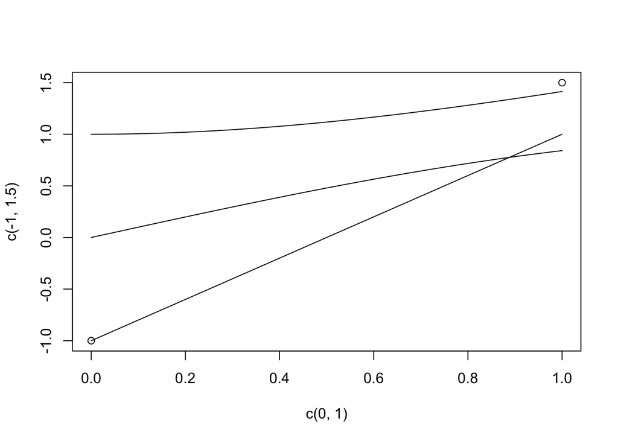

```r
f <- f2

# looping through a list of functions
g1 <- function(x) {
  return(sin(x))
}
g2 <- function(x) {
  return(sqrt(x^2 + 1))
}
g3 <- function(x) {
  return(2 * x - 1)
}
plot(c(0, 1), c(-1, 1.5)) # prepare the graph, specifying X and Y ranges
for (f in c(g1, g2, g3)) plot(f, 0, 1, add = T) # add plot to existing graph
```

## Environment and Scope Issues

A function consists not only of its arguments and body but also of its environment. The latter is made up of the collection of objects present at the time the function is created.

### 9.5.1 The Top-Level Environment

The function `f()` is created at the top level—that is, at the interpreter command prompt—and thus has the top-level environment, which in R output is referred to as `R_GlobalEnv` but which confusingly you refer to in R code as `.GlobalEnv`. The function `ls()` lists the objects of an environment. If you call it at the top level, you get the top-level environment.

```r
w <- 12
f <- function(y) {
  d <- 8
  h <- function() {
    return(d * (w + y))
  }
  return(h())
}
environment(f)
```

```
## <environment: R_GlobalEnv>
```

```r
ls()
```

```
##  [1] "a"                               "affils"
##  [3] "ages"                            "align_legend"
##  [5] "aq"                              "b"
##  [7] "binmarks"                        "c"
##  [9] "csf"                             "ct"
## [11] "cttab"                           "d"
## [13] "d1"                              "d2"
## [15] "d4"                              "d5"
## [17] "data"                            "data2"
## [19] "detach_all_packages"             "dl"
## [21] "dn"                              "dtab"
## [23] "dviz_font_family"                "dviz_font_family_bold"
## [25] "dviz_font_family_bold_condensed" "dviz_font_family_condensed"
## [27] "eq"                              "examsquiz"
## [29] "f"                               "f1"
```

[output cut: 34 more lines]

```r
# ls.str()
```

### 9.5.2 The Scope Hierarchy

If we were working with the C language, we would say that the variable `w` in the previous section is global to `f()`, while d is local to`f()`. Things are similar in R, but R is more hierarchical. In C, we would not have functions defined within functions, as we have with `h()` inside `f()` in our example. Yet, since functions are objects, it is possible to define a function within a function; we are simply creating an object, which we can do anywhere.

Here, we have `h()` being local to `f()`, just like `d`. In such a situation, it makes sense for scope to be hierarchical. Thus, R is set up so that `d`, which is local to `f()`, is in turn global to `h()`. The same is true for `y`, as arguments are considered locals in R. Similarly, the hierarchical nature of scope implies that since `w` is global to `f()`, it is global to `h()` as well. Indeed, we do use `w` within `h()`. In terms of environments then, h()’s environment consists of whatever objects are defined at the time that `h()` assignment is executed.

In other words, if one function is defined within another, then that inner function’s environment consists of the environment of the outer one, plus whatever locals have been created so far within the outer one. With multiple nesting of functions, you have a nested sequence of larger and larger environments, with the “root” consisting of the top-level objects.

```r
f(2)
```

```
## [1] 112
```

The call `f(2)` resulted in setting the local variable `d` to 8, followed by the call `h()`. The latter evaluated `d*(w+y)`—that is, `8*(12+2)`— giving us `112`. Note carefully the role of `w`. The R interpreter found that there was no local variable of that name, so it ascended to the next higher level—in this case, the top level—where it found a variable `w` with value `12`. Keep in mind that `h()` is local to `f()` and invisible at the top level.

### 9.5.3 Functions Have (Almost) No Side Effects

Yet another influence of the functional programming philosophy is that functions do not change nonlocal variables; that is, generally, there are no *side effects*. Roughly speaking, the code in a function has read access to its nonlocal variables, but it does not have write access to them. Our code can appear to reassign those variables, but the action will affect only copies, not the variables themselves.

## 9.6 No Pointers in R

R does not have variables corresponding to pointers or references like those of, say, the C language. For example, you cannot write a function that directly changes its arguments. The argument to `sort()` does not change. If we do want `x` to change in this R code, the solution is to **reassign the arguments**. What if our function has several variables of output? A solution is to gather them together into a list, call the function with this list as an argument, have the function return the list, and then reassign to the original list.

```r
x <- c(13, 5, 12)
sort(x)
```

```
## [1]  5 12 13
```

```r
x
```

```
## [1] 13  5 12
```

```r
# reassigning the arguments
x <- sort(x)
x
```

```
## [1]  5 12 13
```

```r
# function with several variables of output
oddsevens <- function(v) {
  odds <- which(v %% 2 == 1)
  evens <- which(v %% 2 == 1)
  list(o = odds, e = evens)
}
```

# 10 Linting

The code in this RMarkdown is linted with the [lintr package](https://github.com/jimhester/lintr), which is based on the [tidyverse style guide](http://style.tidyverse.org/).

```r
# lintr::lint("main.Rmd", linters =
#               lintr::with_defaults(
#                 commented_code_linter = NULL,
#                 trailing_whitespace_linter = NULL
#                 )
#             )
# if you have additional scripts and want them to be linted too, add them here
# lintr::lint("scripts/my_script.R")
```